# Evidencia02

Para el arbol filogenetico alineamos los nucleotidos de cada secuencia

```r
virus_seq_no_alineadas <- OrientNucleotides(virus_seq_no_alineadas)
```

```
## ========================================================================================================================================================================================================
##
## Time difference of 0.21 secs
```

```r
virus_align_seqs <- AlignSeqs(virus_seq_no_alineadas)
```

```
## Determining distance matrix based on shared 11-mers:
## ================================================================================
##
## Time difference of 0.02 secs
##
## Clustering into groups by similarity:
## ================================================================================
##
## Time difference of 0 secs
##
## Aligning Sequences:
## ================================================================================
##
## Time difference of 0.63 secs
##
## Iteration 1 of 2:
##
## Determining distance matrix based on alignment:
## ================================================================================
##
## Time difference of 0.01 secs
##
## Reclustering into groups by similarity:
## ================================================================================
##
## Time difference of 0 secs
##
## Realigning Sequences:
## ================================================================================
##
## Time difference of 0.53 secs
##
## Iteration 2 of 2:
##
## Determining distance matrix based on alignment:
## ================================================================================
##
## Time difference of 0.01 secs
##
## Reclustering into groups by similarity:
## ================================================================================
##
## Time difference of 0 secs
##
## Realigning Sequences:
## ================================================================================
##
## Time difference of 0.01 secs
```

```r
writeXStringSet(virus_align_seqs, file = "virus_align_seq.fasta")
virus_aligned <- read.alignment("virus_align_seq.fasta", format = "fasta")
```

```r
matriz_distancia <- dist.alignment(virus_aligned, matrix = "similarity")
```

Creación del árbol con el paquete ape:

```r
virus_filogenetico <- nj(matriz_distancia)
class(virus_filogenetico)
```

```
## [1] "phylo"
```

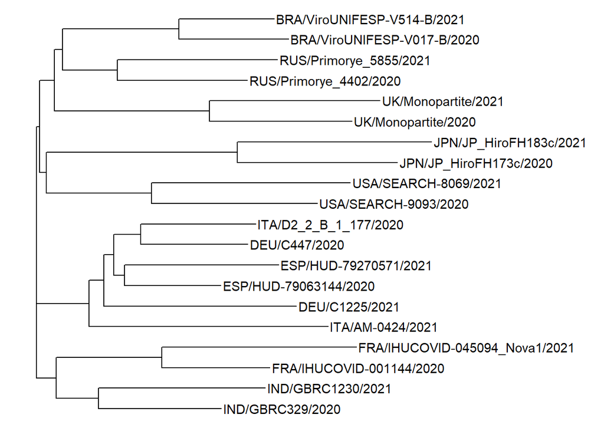

```r
virus_plot_filogenetico <- ladderize(virus_filogenetico)
plot_virus <- ggtree(virus_plot_filogenetico ) + geom_tiplab()+xlim(c(NA, .037))
ggsave("arbolfilogenetico.jpeg", width = 29, height = 8)
plot_virus
```

Aquí tenemos el árbol filogenético de las diferentes variantes con las que hemos trabajado, para empezar primero hay que dejar claro una definición fundamental para este análisis que es el de longitud de rama, esta representa la cantidad de cambios evolutivos que han ocurrido a lo largo de esa rama desde el ancestro común más reciente de los organismos en esa rama. Estos cambios pueden ser, por ejemplo, mutaciones genéticas, inserciones o deleciones de bases en el ADN, o cambios morfológicos.Es importante tener en cuenta que la distancia horizontal no siempre se correlaciona directamente con el tiempo, ya que la tasa de cambio evolutivo puede variar entre diferentes linajes y a lo largo del tiempo.

En general en todo el árbol filogenético podemos ver que la longitud de rama siempre va a ser mayor en las variables de 2021 que las de 2020 respectivamente en cada país esto por lo antes dicho ya que estos pueden presentar más cambios evolutivos. Pero podemos ver que en el caso de Brasil la rama de 2020 es más larga esto no necesariamente tiene que indicar que hay una relación directa con el tiempo como lo que habíamos definido antes

Podemos empezar analizando que aunque todos se supone que tienen que tener un ancestro en común, podemos analizar estos más a profundidad. Las variantes de Estados Unidos, Japón, Reino Unido, Rusia y Brasil tienen el mismo ancestro en común.

Profundizando más en esta rama podemos ver que las variables de estados Unidos esta estrechamente relacionadas con la de japón ya que estos tienen una longitud de rama parecida, aunque las de Japón en general tienen más cambios evolutivos

En el caso de Gran Bretaña este se desprende del mismo ancestro que el de Brasil y Rusia, pero estos últimos dos se desprenden del mismo ancestro por lo cual están más relacionados

Pasando para el otro lado que es el más interesante podemos ver que una de las variantes de italia, la de 2021 se separó de su otra variable puede ser que esta al tener un cambio evolutivo más significativo se haya alejado de la otra pero esto no significa que no sean variantes parecidas o iguales. Después podemos ver que pasa algo parecido con la de alemania del 2021 pero esta si esta mas cerca en ancestros comunes a comparación de la de Italia. Aquí podemos ver que la de España tiene el mismo ancestro común que la de Italia y Alemania. La variable de Italia y Alemania de 2020 son estrechamente iguales ya que viene del mismo ancestro podemos tratar deducir esto ya que son de los primeros países que fueron afectados y los dos están en europa

Por último podemos ver que las de Francia e India vienen del mismo ancestro en comun, claro que esto depende mucho de la variable que se haya colocado ya que en los países hubo diferentes variantes, pero para este caso podemos ver que las dos se parecen mucho aunque la de Francia tiene una longitud de rama mayor lo que puede significar que haya tenido más cambios evolutivos

En conclusion podemos decir que si tiene importancia y si afecta el factor que sean de diferentes paises y que sean de diferentes años como pudimos ver ya que algunas estaban estrechamente relacionadas con otras por sus antecesores y en el caso del año podemos ver que las variables al ser relativamnete mas nuevas han sufrifo mas mutaciones o cambios evolutivos lo que podemos apreciar gracias a la longitud de rama

Referencias

-USA(B.1.429/Epsilon) https://www.ncbi.nlm.nih.gov/nuccore/PP162781

https://www.ncbi.nlm.nih.gov/nuccore/PP162212

-INDIA(B.1.36.8) https://www.ncbi.nlm.nih.gov/nuccore/MT940458

https://www.ncbi.nlm.nih.gov/nuccore/MZ702552

-FRANCIA(B.1.160) https://www.ncbi.nlm.nih.gov/nuccore/OR322150 https://www.ncbi.nlm.nih.gov/nuccore/ON291137

ALEMANIA(B.1.177) https://www.ncbi.nlm.nih.gov/nuccore/OM453862 https://www.ncbi.nlm.nih.gov/nuccore/OM463595

BRAZIL(P.2) https://www.ncbi.nlm.nih.gov/nuccore/OR856800 https://www.ncbi.nlm.nih.gov/nuccore/OR856811

JAPAN(AY.29) https://www.ncbi.nlm.nih.gov/nuccore/OM816720 https://www.ncbi.nlm.nih.gov/nuccore/OM816721

ITALIA(B.1.177) https://www.ncbi.nlm.nih.gov/nuccore/OP288475 https://www.ncbi.nlm.nih.gov/nuccore/OR761900

UK https://www.ncbi.nlm.nih.gov/nuccore/OV089521 https://www.ncbi.nlm.nih.gov/nuccore/OV081111 RUSSIA https://www.ncbi.nlm.nih.gov/nuccore/PP754061 https://www.ncbi.nlm.nih.gov/nuccore/PP158727

ESPAÑA https://www.ncbi.nlm.nih.gov/nuccore/MT953879 https://www.ncbi.nlm.nih.gov/nuccore/MW715080

SOUTHAFRICA https://www.ncbi.nlm.nih.gov/nuccore/PP518928 https://www.ncbi.nlm.nih.gov/nuccore/OM765534

MEXICO https://www.ncbi.nlm.nih.gov/nuccore/OL790173 https://www.ncbi.nlm.nih.gov/nuccore/OK436539

Rabaan AA, Al-Ahmed SH, Haque S, Sah R, Tiwari R, Malik YS, Dhama K, Yatoo MI, Bonilla-Aldana DK, Rodriguez-Morales AJ. SARS-CoV-2, SARS-CoV, and MERS-COV: A comparative overview. Infez Med. 2020 Ahead Of Print Jun 1;28(2):174-184. PMID: 32275259.

Hasöksüz M, Kiliç S, Saraç F. Coronaviruses and SARS-COV-2. Turk J Med Sci. 2020 Apr 21;50(SI-1):549-556. doi: 10.3906/sag-2004-127. PMID: 32293832; PMCID: PMC7195990.

Temmam S, Vongphayloth K, Baquero E, Munier S, Bonomi M, Regnault B, Douangboubpha B, Karami Y, Chrétien D, Sanamxay D, Xayaphet V, Paphaphanh P, Lacoste V, Somlor S, Lakeomany K, Phommavanh N, Pérot P, Dehan O, Amara F, Donati F, Bigot T, Nilges M, Rey FA, van der Werf S, Brey PT, Eloit M. Bat coronaviruses related to SARS-CoV-2 and infectious for human cells. Nature. 2022 Apr;604(7905):330-336. doi: 10.1038/s41586-022-04532-4. Epub 2022 Feb 16. Erratum in: Nature. 2022 Jul;607(7920):E19. PMID: 35172323.

Lvov DK, Alkhovsky SV. [Source of the COVID-19 pandemic: ecology and genetics of coronaviruses (Betacoronavirus: Coronaviridae) SARS-CoV, SARS-CoV-2 (subgenus Sarbecovirus), and MERS-CoV (subgenus Merbecovirus).]. Vopr Virusol. 2020;65(2):62-70. Russian. doi: 10.36233/0507-4088-2020-65-2-62-70. PMID: 32515561.

```r
citation("Biostrings")
```

```
##
##   Pagès H, Aboyoun P, Gentleman R, DebRoy S (2024). _Biostrings:
##   Efficient manipulation of biological strings_. R package version
##   2.70.3, <https://bioconductor.org/packages/Biostrings>.
##
## A BibTeX entry for LaTeX users is
##
##   @Manual{,
##     title = {Biostrings: Efficient manipulation of biological strings},
##     author = {Hervé Pagès and Patrick Aboyoun and Robert Gentleman and Saikat DebRoy},
##     year = {2024},
##     note = {R package version 2.70.3},
##     url = {https://bioconductor.org/packages/Biostrings},
##   }
```

```r
citation("seqinr")
```

```
##
##   Charif, D. and Lobry, J.R. (2007)
##
## A BibTeX entry for LaTeX users is
##
##   @InCollection{,
##     author = {D. Charif and J.R. Lobry},
##     title = {Seqin{R} 1.0-2: a contributed package to the {R} project for statistical computing devoted to biological sequences retrieval and analysis.},
##     booktitle = {Structural approaches to sequence evolution: Molecules, networks, populations},
##     year = {2007},
##     editor = {U. Bastolla and M. Porto and H.E. Roman and M. Vendruscolo},
##     series = {Biological and Medical Physics, Biomedical Engineering},
##     pages = {207-232},
##     address = {New York},
##     publisher = {Springer Verlag},
##     note = {{ISBN :} 978-3-540-35305-8},
##   }
```

```r
citation("adegenet")
```

```
##
##   Jombart, T. (2008) adegenet: a R package for the multivariate
##   analysis of genetic markers. Bioinformatics 24: 1403-1405. doi:
##   10.1093/bioinformatics/btn129
##
##   Jombart T. and Ahmed I. (2011) adegenet 1.3-1: new tools for the
##   analysis of genome-wide SNP data. Bioinformatics. doi:
##   10.1093/bioinformatics/btr521
##
## To see these entries in BibTeX format, use 'print(<citation>,
## bibtex=TRUE)', 'toBibtex(.)', or set
## 'options(citation.bibtex.max=999)'.
```

```r
citation("ape")
```

```
##
##   Paradis E, Schliep K (2019). "ape 5.0: an environment for modern
##   phylogenetics and evolutionary analyses in R." _Bioinformatics_,
##   *35*, 526-528. doi:10.1093/bioinformatics/bty633
##   <https://doi.org/10.1093/bioinformatics/bty633>.
##
## A BibTeX entry for LaTeX users is
##
##   @Article{,
##     title = {ape 5.0: an environment for modern phylogenetics and evolutionary analyses in {R}},
##     author = {Emmanuel Paradis and Klaus Schliep},
##     journal = {Bioinformatics},
##     year = {2019},
##     volume = {35},
##     pages = {526-528},
##     doi = {10.1093/bioinformatics/bty633},
##   }
##
## ape is evolving quickly, so you may want to cite its version number
## (found with 'library(help = ape)' or 'packageVersion("ape")').
```

```r
citation("ggtree")
```

```
##
##   Guangchuang Yu. (2022). Data Integration, Manipulation and
##   Visualization of Phylogenetic Trees (1st edition). Chapman and
##   Hall/CRC. doi:10.1201/9781003279242
##
##   Shuangbin Xu, Lin Li, Xiao Luo, Meijun Chen, Wenli Tang, Li Zhan,
##   Zehan Dai, Tommy T. Lam, Yi Guan, Guangchuang Yu. Ggtree: A
##   serialized data object for visualization of a phylogenetic tree and
##   annotation data. iMeta 2022, 4(1):e56. doi:10.1002/imt2.56
##
##   Guangchuang Yu. Using ggtree to visualize data on tree-like
##   structures. Current Protocols in Bioinformatics, 2020, 69:e96. doi:
##   10.1002/cpbi.96
##
##   Guangchuang Yu, Tommy Tsan-Yuk Lam, Huachen Zhu, Yi Guan. Two methods
##   for mapping and visualizing associated data on phylogeny using
##   ggtree. Molecular Biology and Evolution 2018, 35(2):3041-3043. doi:
##   10.1093/molbev/msy194
##
##   Guangchuang Yu, David Smith, Huachen Zhu, Yi Guan, Tommy Tsan-Yuk
##   Lam. ggtree: an R package for visualization and annotation of
##   phylogenetic trees with their covariates and other associated data.
##   Methods in Ecology and Evolution 2017, 8(1):28-36.
##   doi:10.1111/2041-210X.12628
##
## To see these entries in BibTeX format, use 'print(<citation>,
## bibtex=TRUE)', 'toBibtex(.)', or set
## 'options(citation.bibtex.max=999)'.
```

```r
citation("DECIPHER")
```

```
##
##   Wright ES (2016). "Using DECIPHER v2.0 to Analyze Big Biological
##   Sequence Data in R." _The R Journal_, *8*(1), 352-359.
##
## A BibTeX entry for LaTeX users is
##
##   @Article{,
##     title = {Using DECIPHER v2.0 to Analyze Big Biological Sequence Data in R},
##     author = {Erik S. Wright},
##     journal = {The R Journal},
##     year = {2016},
##     volume = {8},
##     number = {1},
##     pages = {352-359},
##   }
##
## reference section in the function's manual (help) page where available.
```

```r
citation("viridis")
```

```
##
##   Simon Garnier, Noam Ross, Robert Rudis, Antônio P. Camargo, Marco
##   Sciaini, and Cédric Scherer (2024). viridis(Lite) -
##   Colorblind-Friendly Color Maps for R. viridis package version 0.6.5.
##
## A BibTeX entry for LaTeX users is
##
##   @Manual{,
##     title = {{viridis(Lite)} - Colorblind-Friendly Color Maps for R},
##     author = {{Garnier} and {Simon} and {Ross} and {Noam} and {Rudis} and {Robert} and {Camargo} and Antônio Pedro and {Sciaini} and {Marco} and {Scherer} and {Cédric}},
##     year = {2024},
##     note = {viridis package version 0.6.5},
##     url = {https://sjmgarnier.github.io/viridis/},
##     doi = {10.5281/zenodo.4679423},
##   }
```

```r
citation("ggplot2")
```

```
##
##   H. Wickham. ggplot2: Elegant Graphics for Data Analysis.
##   Springer-Verlag New York, 2016.
##
## A BibTeX entry for LaTeX users is
##
##   @Book{,
##     author = {Hadley Wickham},
##     title = {ggplot2: Elegant Graphics for Data Analysis},
##     publisher = {Springer-Verlag New York},
##     year = {2016},
##     isbn = {978-3-319-24277-4},
##     url = {https://ggplot2.tidyverse.org},
##   }
```

```r
citation("tidyverse")
```

```
##
##   Wickham H, Averick M, Bryan J, Chang W, McGowan LD, François R,
##   Grolemund G, Hayes A, Henry L, Hester J, Kuhn M, Pedersen TL, Miller
##   E, Bache SM, Müller K, Ooms J, Robinson D, Seidel DP, Spinu V,
##   Takahashi K, Vaughan D, Wilke C, Woo K, Yutani H (2019). "Welcome to
##   the tidyverse." _Journal of Open Source Software_, *4*(43), 1686.
##   doi:10.21105/joss.01686 <https://doi.org/10.21105/joss.01686>.
##
## A BibTeX entry for LaTeX users is
##
##   @Article{,
##     title = {Welcome to the {tidyverse}},
##     author = {Hadley Wickham and Mara Averick and Jennifer Bryan and Winston Chang and Lucy D'Agostino McGowan and Romain François and Garrett Grolemund and Alex Hayes and Lionel Henry and Jim Hester and Max Kuhn and Thomas Lin Pedersen and Evan Miller and Stephan Milton Bache and Kirill Müller a…
##     year = {2019},
##     journal = {Journal of Open Source Software},
##     volume = {4},
##     number = {43},
##     pages = {1686},
##     doi = {10.21105/joss.01686},
##   }
```

```r
citation("ggplot2")
```

```
##
##   H. Wickham. ggplot2: Elegant Graphics for Data Analysis.
##   Springer-Verlag New York, 2016.
##
## A BibTeX entry for LaTeX users is
##
##   @Book{,
##     author = {Hadley Wickham},
##     title = {ggplot2: Elegant Graphics for Data Analysis},
##     publisher = {Springer-Verlag New York},
##     year = {2016},
##     isbn = {978-3-319-24277-4},
##     url = {https://ggplot2.tidyverse.org},
##   }
```

```r
citation("reshape")
```

```
##
##   H. Wickham. Reshaping data with the reshape package. Journal of
##   Statistical Software, 21(12), 2007.
##
## A BibTeX entry for LaTeX users is
##
##   @Article{,
##     author = {Hadley Wickham},
##     journal = {Journal of Statistical Software},
##     number = {12},
##     title = {Reshaping data with the reshape package},
##     url = {https://www.jstatsoft.org/v21/i12/},
##     volume = {21},
##     year = {2007},
##   }
```

```r
citation("scales")
```

```
##
##   Wickham H, Pedersen T, Seidel D (2023). _scales: Scale Functions for
##   Visualization_. R package version 1.3.0,
##   <https://CRAN.R-project.org/package=scales>.
##
## A BibTeX entry for LaTeX users is
##
##   @Manual{,
##     title = {scales: Scale Functions for Visualization},
##     author = {Hadley Wickham and Thomas Lin Pedersen and Dana Seidel},
##     year = {2023},
##     note = {R package version 1.3.0},
##     url = {https://CRAN.R-project.org/package=scales},
##   }
```